# Lifting Weights - Right And Wrong

Siddharth Samant

15/11/2020

# ============================================================

## Synopsis

# ============================================================

## Data Collection & Feature Characteristics

A detailed synopsis of the data collection process is provided in the research paper [Qualitative Activity Recognition of Weight Lifting Exercises](http://groupware.les.inf.puc-rio.br/public/papers/2013.Velloso.QAR-WLE.pdf). We noted the following:

1. 6 Participants were asked to perform one set of 10 repetitions of the Unilateral Dumbbell Biceps Curl in five different fashions:
   - exactly according to the specification: **Class A**
   - throwing the elbows to the front: **Class B**
   - lifting the dumbbell only halfway: **Class C**
   - lowering the dumbbell only halfway: **Class D**
   - throwing the hips to the front: **Class E**
2. Class A corresponded to the specified execution of the exercise, while the other 4 classes corresponded to common mistakes
3. **Sensors were mounted in users’ glove, armband, lumbar belt, and dumbbell**
4. For data recording, the researchers used Razor inertial measurement units (IMU), which provided **3-axes acceleration, gyroscope and magnetometer data**
5. **For feature extraction, the researchers used a sliding window approach with different lengths from 0.5 second to 2.5 seconds**, with 0.5 second overlap
6. In each step of the sliding window approach, **they calculated features on the Euler angles - roll, pitch and yaw - as well as the raw accelerometer, gyroscope and magnetometer readings**
7. For the Euler angles of each of the four sensors, they calculated eight features: **mean, variance, standard deviation, max, min, amplitude, kurtosis and skewness**, generating in total 96 derived feature sets

# ============================================================

## Data Preprocessing

### 1. Loading Important Packages

We loaded in the `tidyverse` set of packages for more efficient coding. We also loaded in the `caret` package because of its library of extensive modeling tools.

```r
####install packages (ex. install.packages("caret")) if using for the first time
library(tidyverse)
library(caret)
```

### 2. Reading In The Dataset

We read in and explored the training dataset. It had `19622` rows and `160` variables, which could be categorised as follows:

1. The `user_name` variable listed which of the 6 participants performed the physical activity
2. There were 3 variables - `raw_timestamp_part_1`, `raw_timestamp_part_2` and `cvtd_timestamp` - which informed us when the activity was performed
3. The `new_window` variable informed us whether a new sliding window was started at a particular observation. The `num_window` variable counted the total windows - there were a total of 846
4. Columns `8` to `159` contained the measurement variables - from `row_belt` to `magnet_forearm_z`
5. The final column `classe` contained the response - it listed the classes of the observations

```r
#Download the training set, and then read it in
download.file("https://d396qusza40orc.cloudfront.net/predmachlearn/pml-training.csv",
              destfile = "pml_training.csv")

trainingWeights <- read_csv("pml_training.csv", na = c("#DIV/0!", "NA"))
```

### 3. Dealing with Missing Values

We conducted an analysis of variable-wise missing values. Out of the 160 variables in the dataset:

- 60 variables had no missing values
- 94 variables had 19,216-19,301 missing values; i.e., close to 98% observations had missing values
- For 6 variables, all observations were missing
- Missing values seemed to be well distributed among the 5 response classes
- Most of the variables with missing values were those calculating the summary measurements - skewness, kurtosis, maximum, minimum, average, variance, amplitude, and standard deviation

This left us with 3 possible courses of action:

1. **Create a new set with only 60 variables**
2. **Remove all observations with a majority of missing values**
3. **Impute missing values**

In the end, **we decided to create a new dataset with only the 60 non-missing-values predictors**. Our rationale was:

- The summary variables were encoding information that was already present in the other variables - removing the former would hopefully not impact our model’s ability to correctly predict the response
- Removing the missing-value variables would allow us to use all the 19622 observations, and consequently fit a model that had enough samples to model the true relationship between the predictors and the response

```r
#finding variable-wise missing values in trainingWeights
nonNA <- data.frame(x = apply(trainingWeights, 2, function(x)
        sum(!is.na(x))))
nonNA$variable <- row.names(nonNA)
row.names(nonNA) <- 1:160


#removing rows indicating missing-value-predictors from nonNA
nonNA <- nonNA[nonNA$x == nrow(trainingWeights),]

#creating trainingWeightsNew with only non-missing-value predictors
mainVar <- names(trainingWeights) %in% unique(nonNA$variable)
trainingWeightsNew <- trainingWeights %>%
        select(names(trainingWeights)[mainVar])
```

### 4. Data Streamlining

We streamlined the data further as follows:

1. We removed *near zero variance* predictors, which can have a disproportionate impact on some models
2. We removed the auto-generated row-number variable `X1`, the time-stamp variables, and the window variables - based on a cursory look at the distribution of these variables, we did not believe that they would be linked with the response
3. We encoded `user_name` and the response variable `classe` as factors
4. We decomposed the `user_name` predictor as a set of binary dummy variables, so that it would work better with tree-based models in particular

```r
#near zero variables search
nzv <- nearZeroVar(trainingWeightsNew)
trainingWeightsNew <- trainingWeightsNew[,-nzv]

#removing irrelevant predictors
trainingWeightsNew$raw_timestamp_part_1 <- NULL
trainingWeightsNew$raw_timestamp_part_2 <- NULL
trainingWeightsNew$cvtd_timestamp <- NULL
trainingWeightsNew$X1 <- NULL
trainingWeightsNew$num_window <- NULL

#converting categorical variables to factors
trainingWeightsNew$user_name <- as.factor(trainingWeightsNew$user_name)
trainingWeightsNew$classe <- as.factor(trainingWeightsNew$classe)

###creating new dataset trDummyUsers with dummy predictors for each user
trDummyUsers <- trainingWeightsNew %>%
        mutate(adelmo = ifelse(user_name == "adelmo", 1, 0),
               carlitos = ifelse(user_name == "carlitos", 1, 0),
               charles = ifelse(user_name == "charles", 1, 0),
               eurico = ifelse(user_name == "eurico", 1, 0),
               jeremy = ifelse(user_name == "jeremy", 1, 0),
               pedro = ifelse(user_name == "pedro", 1, 0)) %>%
        select(roll_belt:magnet_forearm_z, adelmo:pedro, classe)
```

### 5. Reducing Skewness

Skewed variables may reduce the efficacy of certain models. We used the `skewness` function in the `e1071` package to compute the skewness of each variable, and to display the variables with the highest absolute skewness. We also loaded the `kableExtra` package for its table formatting options.

```r
#load the e1071 package
library(e1071)
library(kableExtra)

#compute skewness for each variable (exclude dummy variables and the response)
sk <- data.frame(skewness = apply(trDummyUsers[,-53:-59], 2, skewness))

#display the variables with the highest possible skewness
sk <- sk %>%
        mutate(variable = row.names(sk)) %>%
        select(variable, skewness) %>%
        arrange(desc(abs(skewness)))
row.names(sk) <- NULL
knitr::kable(
        sk %>% head(),
        align = "cc"
        ) %>%
        kable_styling(full_width = TRUE)
```

| variable | skewness |
| --- | --- |
| gyros_dumbbell_z | 135.953437 |
| gyros_dumbbell_x | -126.321221 |
| gyros_forearm_z | 116.076194 |
| gyros_forearm_y | 51.323792 |
| gyros_dumbbell_y | 31.648274 |
| magnet_belt_y | -2.235841 |

Skewness values greater than 1 or smaller than -1 indicate a skewed variable. The above table indicated that 5 variables in particular were highly skewed (`gyros_dumbbell_z`, `gyros_dumbbell_x`, `gyros_forearm_z`, `gyros_forearm_y`, and `gyros_dumbbell_y`).

Further investigation lead us to the conclusion that this high skewness was the result of only 1 observation in the dataset. We removed this observation and recomputed the skewness measure.

```r
#remove the high outlier observation from trDummyUsers
attach(trDummyUsers)
trDummyUsers1 <- trDummyUsers[gyros_dumbbell_z != range(gyros_dumbbell_z)[2],]

#compute skewness for each variable
sk1 <- data.frame(skewness = apply(trDummyUsers1[,-53:-59], 2, skewness))

#display the variables with the highest possible skewness
sk1 <- sk1 %>%
        mutate(variable = row.names(sk1)) %>%
        select(variable, skewness) %>%
        arrange(desc(abs(skewness)))
row.names(sk1) <- NULL
knitr::kable(
        sk1 %>% head(),
        align = "cc"
        ) %>%
        kable_styling(full_width = TRUE)
```

| variable | skewness |
| --- | --- |
| magnet_belt_y | -2.235837 |
| magnet_dumbbell_y | -1.809947 |
| magnet_dumbbell_x | 1.694105 |
| magnet_belt_x | 1.433137 |
| magnet_forearm_z | -1.221237 |
| magnet_arm_z | -1.140318 |

The skewness values improved substantially, which indicated the outsize impact of that one outlier observation. We illustrate this below by showing the distribution of one of the highly skewed variables before and after removing the outlier.

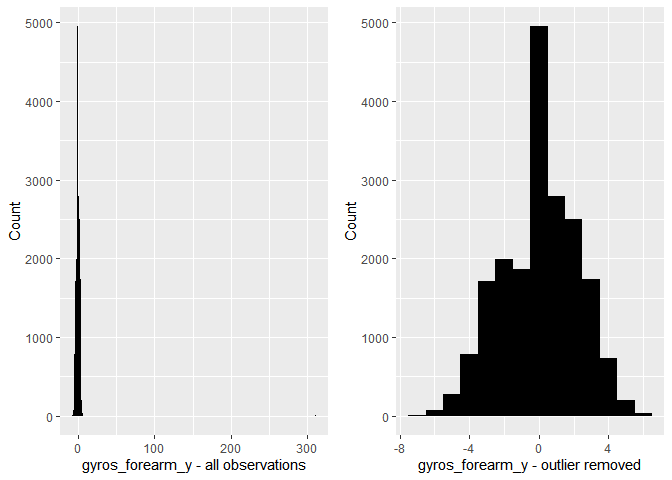

```r
#histogram plot for gyros_forearm_y variable before outlier removal
x1 <- ggplot(trDummyUsers, aes(gyros_forearm_y)) +
        geom_histogram(binwidth = 1, fill = "black") +
        xlab("gyros_forearm_y - all observations") +
        ylab("Count")

#histogram plot for gyros_forearm_y variable before outlier removal
x2 <- ggplot(trDummyUsers1, aes(gyros_forearm_y)) +
        geom_histogram(binwidth = 1, fill = "black") +
        xlab("gyros_forearm_y - outlier removed") +
        ylab("Count")

#display the histogram plots side-by-side
gridExtra::grid.arrange(x1, x2, ncol = 2)
```

### 6. Removing Highly Correlated Predictors

We started off by constructing the correlation matrix between each pair of predictors (apart from the dummy variables). We then used the `corrplot` package to visualise the correlation plot, ordering the variables using hierarchical clustering, so that highly correlated variables are placed next to one another. As we can see, there were high absolute correlations between many variables.

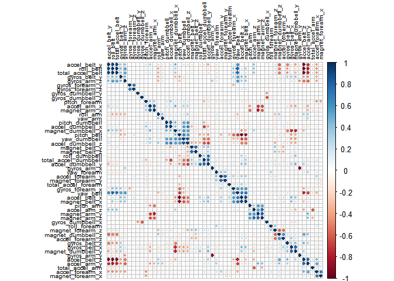

```r
#computing correlation between each pair of variables
correlations <- cor(trDummyUsers1[,-53:-59])

#load the corrplot library and display the correlation plot
library(corrplot)
corrplot(correlations, order = "hclust", tl.cex = 0.65, tl.col = "black")
```

Next, we removed predictors with an absolute correlation over 0.75 from the dataset, in order to improve model performance. The `findCorrelation` function removes one of each pair of highly correlated predictors.

```r
#removing high correlated variables from the dataset
high <- findCorrelation(correlations, cutoff = 0.75, exact = TRUE)
trDummyUsers2 <- trDummyUsers1[,-high]
```

Our final dataset contained 19621 observations and 41 variables (including the response).

# ============================================================

## Model Selection

### 1. Training & Validation Sets

Our strategy for selecting the best model was informed both by the desire to capture the true fit, and computing constraints:

1. 50% of the dataset was used as a training set
2. The training set was centered and scaled before fitting each model
3. Each model was tuned over 10 different values of its tuning parameters
4. We used 10-fold cross validation as our resampling technique. This was because it balanced both model bias and variance (especially considering the large sample size), and because it was computationally efficient
5. Each model was then assessed for its accuracy on the validation set, which contained the remaining 50% of the dataset. The out-of-sample error rate was also calculated using this accuracy measure

```r
#partition the data basis the response
halfTrain <- createDataPartition(y = trDummyUsers2$classe, p = 0.5,
                                 list = FALSE)

#create the training and validation sets
trTrain50 <- trDummyUsers2[halfTrain,]
trVal50 <- trDummyUsers2[-halfTrain,]
```

### 2. Shortlisted Models

We decided to use a mix of parametric and non-parametric model techniques so that we could select the best possible model:

1. Linear Discriminant Analysis (LDA)
2. Quadratic Discriminant Analysis (QDA)
3. Penalised LDA
4. Classification Tree
5. Bagging
6. Support Vector Machine (SVM)
7. Naive Bayes
8. K Nearest Neighbours (KNN)
9. Random Forest
10. Boosting

In the next few sections, we fit only the 3 models that returned the highest validation set accuracy - **Random Forest, Bagging & K Nearest Neighbour** - and 2 other parametric models - **Linear Discriminant Analysis & Naive Bayes**. This was done for the purposes of computational efficiency.

### 3. Linear Discriminant Analysis (LDA)

LDA is a parametric modeling technique that uses maximum likelihood to predict the response class.

```r
#set seed and train best LDA model
set.seed(100)
ldaFit <- train(x = trTrain50[,-41], y = trTrain50$classe,
                method = "lda",
                preProcess = c("center","scale"),
                tuneLength = 10,
                trControl = trainControl(method = "cv",
                                         allowParallel = TRUE))

#predict the response on the validation set
ldaPredVal <- predict(ldaFit, trVal50)

#confusion matrix - actual vs. predicted response
ConfusionMatrix_LDA <- list(Table = confusionMatrix(ldaPredVal, trVal50$classe)$table,
     Accuracy = round(confusionMatrix(ldaPredVal,
                           trVal50$classe)$overall[c(1,3,4,6)],3))
ConfusionMatrix_LDA
```

```
## $Table
##           Reference
## Prediction    A    B    C    D    E
##          A 2105  357  181  102  113
##          B  197 1000  169  168  316
##          C  262  235 1031  231  222
##          D  213  132  262 1001  162
##          E   12  174   68  106  990
##
## $Accuracy
##       Accuracy  AccuracyLower  AccuracyUpper AccuracyPValue
##          0.625          0.615          0.634          0.000
```

LDA provided an overall classification accuracy of only **0.625** on the validation set. Thus, the **out-of-sample error rate** is **0.375**.

### 4. Bagged Trees

Bagging aggregates the results of many bootstrapped trees, and predicts the response class by majority vote.

```r
#set seed and train best LDA model
set.seed(100)
bagFit <- train(x = trTrain50[,-41], y = trTrain50$classe,
                method = "treebag",
                preProcess = c("center","scale"),
                tuneLength = 10,
                trControl = trainControl(method = "cv",
                                         allowParallel = TRUE))

#predict the response on the validation set
bagPredVal <- predict(bagFit, trVal50)

#confusion matrix - actual vs. predicted response
ConfusionMatrix_Bagging <- list(Table = confusionMatrix(bagPredVal, trVal50$classe)$table,
     Accuracy = round(confusionMatrix(bagPredVal,
                           trVal50$classe)$overall[c(1,3,4,6)],3))
ConfusionMatrix_Bagging
```

```
## $Table
##           Reference
## Prediction    A    B    C    D    E
##          A 2745   39    5    5    1
##          B   30 1810   34   10   16
##          C    4   34 1644   50    4
##          D   10   12   27 1528   26
##          E    0    3    1   15 1756
##
## $Accuracy
##       Accuracy  AccuracyLower  AccuracyUpper AccuracyPValue
##          0.967          0.963          0.970          0.000
```

Bagging provided a high classification accuracy of **0.967** on the validation set. Thus, the **out-of-sample error rate** is **0.033**.

### 5. Naive Bayes

Naive Bayes is a parametric modeling technique that uses Bayes’ Rule to predict the response class. It assumes that predictors are independent pf each other.

```r
#set seed and train best nb model
set.seed(100)
nbFit <- train(x = trTrain50[,-41], y = trTrain50$classe,
                method = "naive_bayes",
                preProcess = c("center","scale"),
                tuneLength = 10,
                trControl = trainControl(method = "cv",
                                         allowParallel = TRUE))

#predict the response on the validation set
nbPredVal <- predict(nbFit, trVal50)

#confusion matrix - actual vs. predicted response
ConfusionMatrix_NB <- list(Table = confusionMatrix(nbPredVal, trVal50$classe)$table,
     Accuracy = round(confusionMatrix(nbPredVal,
                           trVal50$classe)$overall[c(1,3,4,6)],3))
ConfusionMatrix_NB
```

```
## $Table
##           Reference
## Prediction    A    B    C    D    E
##          A 2050  150  128   97   61
##          B  186 1244  117   19  196
##          C  243  244 1337  302  108
##          D  273  153  101 1078   69
##          E   37  107   28  112 1369
##
## $Accuracy
##       Accuracy  AccuracyLower  AccuracyUpper AccuracyPValue
##          0.722          0.713          0.730          0.000
```

Naive Bayes provided an overall classification accuracy of only **0.722** on the validation set. Thus, the **out-of-sample error rate** is **0.278**.

### 6. Random Forest

Random Forest is similar to Bagging, except that only a subset of the predictors are considered at each split of the decision trees. We reduced the cross-validation folds to 5 for computational reasons.

```r
#set seed and train best rf model
set.seed(100)
rfFit <- train(x = trTrain50[,-41], y = trTrain50$classe,
                method = "rf",
                preProcess = c("center","scale"),
                tuneLength = 10,
                trControl = trainControl(method = "cv",
                                         number = 5,
                                         allowParallel = TRUE))

#predict the response on the validation set
rfPredVal <- predict(rfFit, trVal50)

#confusion matrix - actual vs. predicted response
ConfusionMatrix_RF <- list(Table = confusionMatrix(rfPredVal, trVal50$classe)$table,
     Accuracy = round(confusionMatrix(rfPredVal,
                           trVal50$classe)$overall[c(1,3,4,6)],3))
ConfusionMatrix_RF
```

```
## $Table
##           Reference
## Prediction    A    B    C    D    E
##          A 2782   21    0    2    0
##          B    5 1866   23    0    0
##          C    1   10 1678   45    0
##          D    1    0   10 1561    6
##          E    0    1    0    0 1797
##
## $Accuracy
##       Accuracy  AccuracyLower  AccuracyUpper AccuracyPValue
##          0.987          0.985          0.989          0.000
```

Random Forest provided a high classification accuracy of **0.987** on the validation set. Thus, the **out-of-sample error rate** is **0.013**.

### 7. K Nearest Neighbours (KNN)

KNN is a non-parametric modeling technique that classifies an observation based on the response of the “k” observations closest to it.

```r
#set seed and train best knn model
set.seed(100)
knnFit <- train(x = trTrain50[,-41], y = trTrain50$classe,
                method = "knn",
                preProcess = c("center","scale"),
                tuneGrid = data.frame(.k = seq(1, 50, by = 5)),
                trControl = trainControl(method = "cv",
                                         allowParallel = TRUE))

#predict the response on the validation set
knnPredVal <- predict(knnFit, trVal50)

#confusion matrix - actual vs. predicted response
ConfusionMatrix_KNN <- list(Table = confusionMatrix(knnPredVal, trVal50$classe)$table,
     Accuracy = round(confusionMatrix(knnPredVal,
                           trVal50$classe)$overall[c(1,3,4,6)],3))
ConfusionMatrix_KNN
```

```
## $Table
##           Reference
## Prediction    A    B    C    D    E
##          A 2776   37    4    0    6
##          B    8 1822   25    1   13
##          C    1   28 1659   48    7
##          D    2    6   16 1553    6
##          E    2    5    7    6 1771
##
## $Accuracy
##       Accuracy  AccuracyLower  AccuracyUpper AccuracyPValue
##          0.977          0.974          0.980          0.000
```

KNN provided a high classification accuracy of **0.977** on the validation set. Thus, the **out-of-sample error rate** is **0.023**.

The following plot shows the comparison of the 5 models, in terms of their accuracy. **Random Forest, K Nearest Neighbours and Bagging all had high accuracy**, while **Linear Discriminant Analysis and Naive Bayes were much less accurate**.

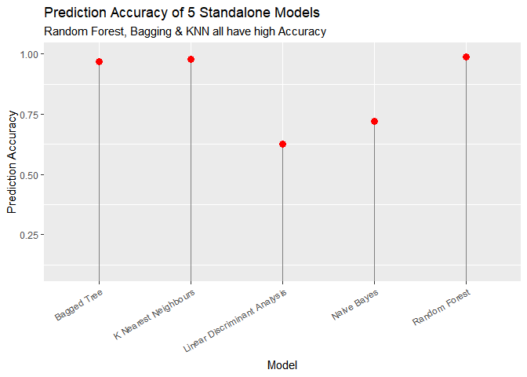

```r
#save the prediction accuracy of each model as new objects
ldaCM <- round(confusionMatrix(ldaPredVal, trVal50$classe)$overall[c(1,3,4)],4)
bagCM <- round(confusionMatrix(bagPredVal, trVal50$classe)$overall[c(1,3,4)],4)
nbCM <- round(confusionMatrix(nbPredVal, trVal50$classe)$overall[c(1,3,4)],4)
rfCM <- round(confusionMatrix(rfPredVal, trVal50$classe)$overall[c(1,3,4)],4)
knnCM <- round(confusionMatrix(knnPredVal, trVal50$classe)$overall[c(1,3,4)],4)

#create a dataframe that stores the accuracy & confidence intervals of all 5 models
finalCM <- data.frame(rbind(ldaCM, bagCM, nbCM, rfCM, knnCM)) %>%
        mutate(Model = c("Linear Discriminant Analysis", "Bagged Tree",
                         "Naive Bayes", "Random Forest", "K Nearest Neighbours"),
               CILower = AccuracyLower,
               CIUpper = AccuracyUpper) %>%
        select(Model, Accuracy, CILower, CIUpper) %>%
        arrange(Model)
row.names(finalCM) <- NULL

#visualise the prediction accuracy of all 5 models
ggplot(finalCM, aes(Accuracy, Model)) +
        geom_segment(aes(yend = Model), xend = 0, colour = "grey50") +
        geom_point(size = 3, colour = "red") +
        theme(panel.grid.major.y = element_blank()) +
        theme(axis.text.x = element_text(angle=30, hjust=1, vjust=1)) +
        xlim(0.1,1) +
        coord_flip() +
        labs(title = "Prediction Accuracy of 5 Standalone Models",
             subtitle = "Random Forest, Bagging & KNN all have high Accuracy",
             y = "Model",
             x = "Prediction Accuracy")
```

### 8. Majority Vote Ensemble Model

**Random Forest, Bagging and K Nearest Neighbours all returned very high prediction accuracy on the validation set**. Instead of choosing one model, we first explored the performance of a model which combined the predictions of these 3 models and returned the majority vote.

```r
#create a data frame that combines the predictions of the 3 best models
predDF <- data.frame(rfPredVal, bagPredVal, knnPredVal)

#add a factor variable that contains the majority vote of the 3 model predictions
majority = apply(predDF, 1, function(x) names(which.max(table(x))))
predDF$majority  <- as.factor(majority)

#confusion matrix - actual vs. predicted response
ConfusionMatrix_MVE <- list(Table = confusionMatrix(predDF$majority, trVal50$classe)$table,
     Accuracy = round(confusionMatrix(predDF$majority,
                           trVal50$classe)$overall[c(1,3,4,6)],3))
ConfusionMatrix_MVE
```

```
## $Table
##           Reference
## Prediction    A    B    C    D    E
##          A 2785   24    0    2    0
##          B    3 1863   23    0    4
##          C    0   11 1679   43    1
##          D    1    0    9 1562    6
##          E    0    0    0    1 1792
##
## $Accuracy
##       Accuracy  AccuracyLower  AccuracyUpper AccuracyPValue
##          0.987          0.985          0.989          0.000
```

The model had an accuracy of **0.987** when tested on the validation set. Thus, the **out-of-sample error rate** is **0.013**.